# ESM 206 Lab 6

Tommy King

11/2/2021

```r
knitr::opts_chunk$set(echo = TRUE, warning = FALSE, message = FALSE)
library(tidyverse)
library(palmerpenguins)
library(broom)
library(equatiomatic)
```

## Rank based test example

Mann-Whitney U (non-parametric alternative to an unpaired or independent 2-sample t-test).

H0: Equal ranks (or medians) HA: Ranks are not equal (or medians are not equal)

### Create samples

`set.seed()` to create “pseudorandom but reproducible sample”

```r
set.seed(1414)
gp_1 <- sample.int(20, size = 15, replace = TRUE)

set.seed(1424)
gp_2 <- sample.int(30, size = 15, replace = TRUE)
```

Take a quick look at the distributinos using `hist()`

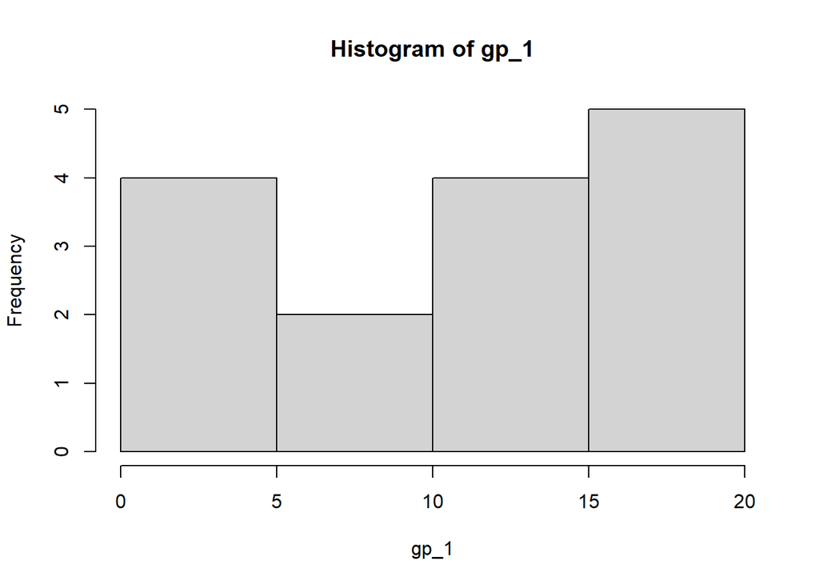

```r
hist(gp_1)
```

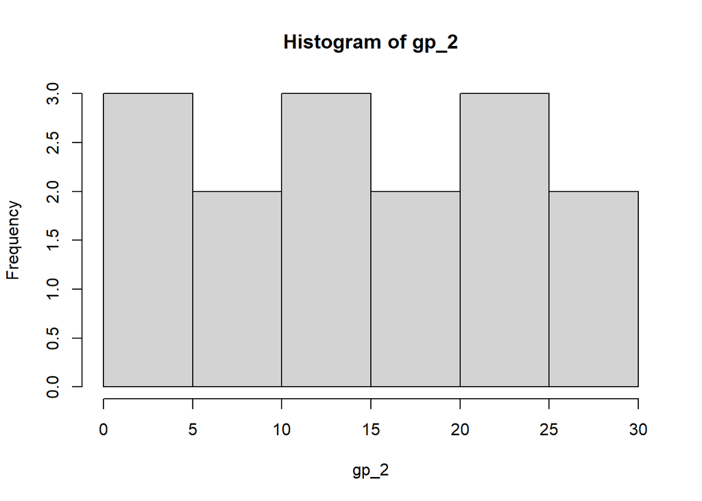

```r
hist(gp_2)
```

Try a t-test so that we can compare the results.

```r
ttest <- t.test(gp_1, gp_2)

# if these data were paired, I can just add the argument `paired = "TRUE" ` within the t-test() function.
```

This p-value means that if our samples are drawn from populations with the same mean (i.e. if the null hypothesis is true), there is 0.2 probability of finding sample means *at least as different* as mine by random chance.

### Mann Whitney U rank based test

We will use the `wilcox.test()` function to performa a two-sample rank-based test.

```r
mwu <- wilcox.test(gp_1, gp_2)
```

This p-value means that if our samples are drawn from populations with the same median, there is a 28% chance of finding sample medians at least as different as ours by random chance.

NO signigicant difference in medians (Mann Whitney U; U = 86, p = 0.28)

Exmaple text for reporting: “The medians of group A (M = 22.4g) and group B (M= 31.2 g) did not differ significantly (Mann Whitney U, …)”

## SImple Linear regression

Two *continuous quantitative* variables that you are trying to understand the relationship between, and you think tthat a linear relationship makes sense.

Use the `penguins` data from {palmerpenguins}, exploring flipper length (x) versus body mass (y).

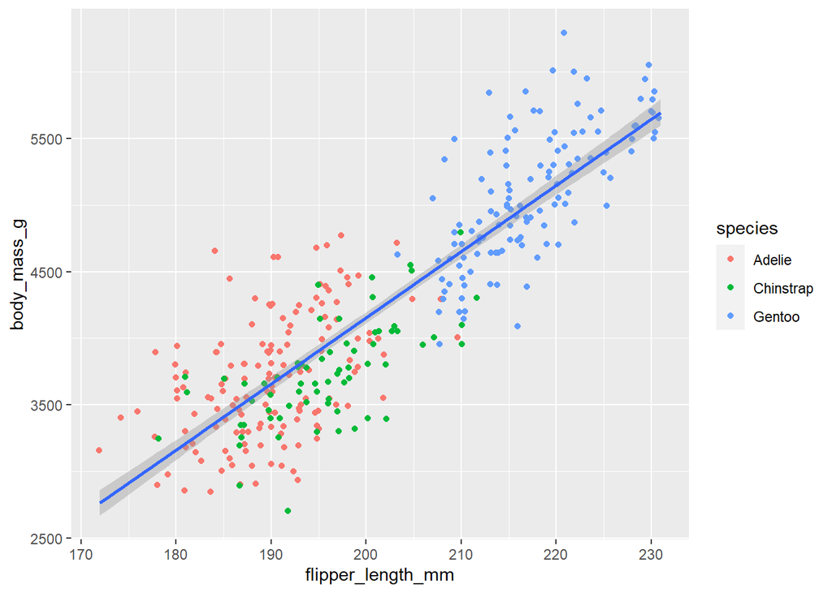

```r
# MAke an exploratory scatterplot of penguin flipper length on x-axis and body mass on y-axis.
ggplot(data = penguins, aes(x = flipper_length_mm, y = body_mass_g)) +
  geom_jitter(aes(color = species)) +
  geom_smooth(method = "lm")
```

### Find the Model estimates or coefficients

Use the `lm()` function for linear model

```r
penguin_lm <- lm(body_mass_g ~ flipper_length_mm, data = penguins)
```

Model Coefficients: -5780.8313581, 49.6855664 Flipper length coefficient: 49.6855664

### USe `broom::tidy()` to get a tidy output from lm()

```r
penguin_lm_tidy <- tidy(penguin_lm)

penguin_lm_tidy
```

```
## # A tibble: 2 x 5
##   term              estimate std.error statistic   p.value
##   <chr>                <dbl>     <dbl>     <dbl>     <dbl>
## 1 (Intercept)        -5781.     306.       -18.9 5.59e- 55
## 2 flipper_length_mm     49.7      1.52      32.7 4.37e-107
```

### Use `broom::glance()` to get output of model fit and statistical significance

```r
penguin_lm_glance <- glance(penguin_lm)
```

### Use equatiomatic:: extract_eq() to return model in LaTex

```r
extract_eq(model = penguin_lm, use_coefs = TRUE) # add the `use_coefs()` function to put in the actual coefficient values in the equation
```

$$\operatorname{\widehat{body\_mass\_g}} = -5780.83 + 49.69(\operatorname{flipper\_length\_mm})$$